# Version control with Git and GitHub

A beginner workshop

Author

Melina Klostermann

Published

June 24, 2026

# 1 Workshop goals

By the end of this workshop, you should be able to:

- explain the difference between **Git** and **GitHub**
- create a Git repository for a project
- save project snapshots using commits
- connect a local repository to GitHub
- push and pull changes
- (use Git from the terminal and from Posit/RStudio)

The main goal is not to learn every Git command. The goal is to understand the basic workflow well enough to use Git in your own research projects.

# 2 Why use version control?

Most researchers eventually create files like this:

```
analysis.R
analysis_new.R
analysis_final.R
analysis_final2.R
analysis_final_REAL.R
```

This is understandable, but it quickly becomes difficult to answer basic questions:

- Which version produced the figure in the manuscript?
- What changed since last week?
- Can I undo the bug I introduced yesterday?
- Can my collaborator safely edit the project too?
- Can I prove what code was used for a result?

Git helps solve these problems by tracking the history of your project.

A useful mental model:

| Research problem | Git solution |
| --- | --- |
| I want to save a working version | Commit |
| I want to see what changed | Diff |
| I broke something | Go back to an older version |
| I want to share code | Push to GitHub/GitLab/etc. |
| I want to work with others | Pull, push, branches, pull requests |

# 3 What are Git and GitHub?

## 3.1 Git

Git is software installed on your computer. It tracks changes in files inside a project folder.

A project folder tracked by Git is called a **repository**.

A saved snapshot of your project is called a **commit**.

Git works especially well for plain-text files, for example:

- `.R` scripts;
- `.Rmd` or `.qmd` documents;
- `.py` scripts;
- `.sh` scripts;
- text files;
- small tables such as `.csv` or `.tsv` files.

Git works less well for very large or binary files, for example:

- FASTQ files;
- BAM files;
- large images;
- large Excel files;
- large result folders.

These files often need different storage solutions.

## 3.2 GitHub

GitHub is an online platform where Git repositories can be hosted.

Git is local. GitHub is online.

You can use Git without GitHub, but GitHub repositories are based on Git.

## 3.3 Git & GitHub workflow

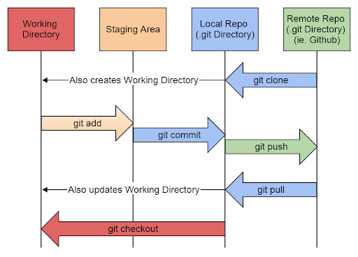

Git workflow overview

| Term | Meaning |
| --- | --- |
| Repository | A project folder tracked by Git |
| Commit | A saved snapshot of the project |
| Staging area | Files selected for the next commit |
| Push | Upload local commits to GitHub |
| Pull | Download new changes from GitHub |
| Clone | Download a GitHub repository to your computer |
| Remote | The online version of your repository |
| Branch | A parallel version of the project |
| Pull request | A proposed change on GitHub |

## 3.4 Alternatives

### 3.4.1 Alternatives to GitHub

GitHub is widely used, but it is not the only option. Alternatives are:

- GitLab
- Bitbucket
- Codeberg
- Self-hosted GitLab or Gitea

Important point:

> These are hosting platforms. Git is the underlying version control system to all of them.

### 3.4.2 Alternatives to Git

Older or less common version control systems include:

- Subversion/SVN;
- Mercurial.

However, Git is currently the most common choice in research software, bioinformatics, and open-source projects.

# 4 Useful links

Some useful references:

- Git documentation: https://git-scm.com/doc
- GitHub Docs: https://docs.github.com/
- Happy Git and GitHub for the useR: https://happygitwithr.com/
- Posit/RStudio version control guide: https://support.posit.co/hc/en-us/articles/200532077-Version-Control-with-Git-and-SVN

# 5 Get started

## 5.1 Install Git

Check whether Git is already installed:

```bash
git --version
```

If Git is not installed, install it using the appropriate method for your operating system.

### 5.1.1 Windows and macOS

Download Git from:

https://git-scm.com/downloads

### 5.1.2 Debian/Ubuntu

```bash
sudo apt update
sudo apt install git
```

### 5.1.3 Fedora/RedHat

```bash
sudo dnf install git
```

**Task:** Install Git on the computer you usually work with and check the installation with `git --version`.

## 5.2 Create a GitHub account

Create a GitHub account here:

https://github.com/

**Task:** Create a GitHub account or log into your existing account.

## 5.3 Configure Git once

Git needs to know your name and email address. This information is attached to your commits.

Open a terminal and run:

```bash
git config --global user.name "Your Name"
git config --global user.email "email@example.com"
```

Check the settings:

```bash
git config --global user.name
git config --global user.email
```

The email address should usually match an email address connected to your GitHub account. You can also use a GitHub no-reply email address.

**Task:** Set your Git name and email address.

# 6 Part 1: Git in the terminal

We will first use Git directly in the terminal.

## 6.1 Create a new folder

```bash
mkdir my_new_git_repository
cd my_new_git_repository
```

## 6.2 Initialize a Git repository

```bash
git init
```

This turns the current folder into a Git repository.

Check the status:

```bash
git status
```

At this point, Git is tracking the folder, but no files have been committed yet.

## 6.3 Create a file

```bash
echo "# My first Git repository" > README.md
```

Check the status again:

```bash
git status
```

Git should show `README.md` as an untracked file.

## 6.4 The basic Git workflow

Git has three important states:

```
Working directory
       ↓ git add
Staging area
       ↓ git commit
Repository history
```

**The working directory** contains your current files.

**The staging area** contains files selected for the next commit.

**The repository history** contains saved snapshots.

### 6.4.1 Stage a file

```bash
git add README.md
```

Check the status:

```bash
git status
```

The file is now staged.

### 6.4.2 Commit a file

```bash
git commit -m "Add README"
```

This saves a snapshot of the staged file.

Check the history:

```bash
git log --oneline
```

### 6.4.3 Modify a file

```bash
echo "These are my workshop notes." >> README.md
```

Check what changed:

```bash
git diff
```

Check the status:

```bash
git status
```

Stage and commit the change:

```bash
git add README.md
git commit -m "Add workshop notes"
```

Check the history:

```bash
git log --oneline
```

**Task:** Create a new repository in the terminal, add a README file, and make two commits.

## 6.5 Ignoring files with `.gitignore`

Not every file in your project should be tracked by Git.

Temporary files, automatically generated outputs, large datasets, and personal settings often change frequently and would clutter the repository history.

Git uses a file called `.gitignore` to define which files and folders should be ignored.

Create a file called `.gitignore` in the root directory of your project:

```bash
touch .gitignore
```

You can then add patterns for files that Git should ignore.

For example do not commit:

- passwords;
- access tokens;
- huge sequencing files;
- large result folders;
- temporary files.

Also, make sure that you only use private GitHub repositories for:

- patient data;
- unpublished sensitive data;

Example for an R project:

```
# R session files
.Rhistory
.RData
.Ruserdata

# RStudio files
.Rproj.user/

# Generated reports
*.html
*.pdf

# Figures
figures/

# Data files
data/raw/
**.fastq
**.rds
**.bam
**.bed

# Operating system files
.DS_Store
Thumbs.db
```

After saving the `.gitignore` file, check which files Git tracks:

```bash
git status
```

Ignored files will no longer appear in the output.

You can commit the `.gitignore` file itself so that everyone working on the project uses the same rules:

```bash
git add .gitignore
git commit -m "Add gitignore file"
```

> **Important:** `.gitignore` only affects files that are not already tracked by Git.

If a file was committed previously, you must remove it from Git’s tracking before it can be ignored:

```bash
git rm --cached filename
```

and then commit the change:

```bash
git commit -m "Stop tracking generated files"
```

**Task:** Create a `.gitignore` file for your project and add at least three file types or folders that should not be version controlled.

# 7 Part 2: Connect Git to GitHub from the terminal

Now we will connect the local Git repository to GitHub.

## 7.1 Create an empty repository on GitHub

On GitHub:

1. Click **New repository**.
2. Give it a name, for example `my_new_repository`.
3. Do not add a README file if you already created one locally.
4. Create the repository.

## 7.2 Authentication: HTTPS, tokens, and SSH

When pushing to GitHub, you will be asked to authenticate.

There are two common approaches:

1. **HTTPS with a personal access token**
2. **SSH key**

For a repository owned by you, I will explain the SSH version here. For personal access tokens you can find instructions at:

https://docs.github.com/en/authentication/keeping-your-account-and-data-secure/managing-your-personal-access-tokens

### 7.2.1 via SSH key

Generate an SSH key:

```bash
ssh-keygen -t ed25519 -C "email@example.com"
```

Press enter to accept the default file location. When asked for a passphrase you can press enter to leave it empthy.

Start the SSH agent:

```bash
eval "$(ssh-agent -s)"
ssh-add ~/.ssh/id_ed25519
```

Show the public key:

```bash
cat ~/.ssh/id_ed25519.pub
```

Copy the output and add it to GitHub:

GitHub → Settings → SSH and GPG keys → New SSH key

[figure not shown]

## 7.3 Add GitHub as remote

### 7.3.1 Via SSH:

```bash
git remote add origin git@github.com:USERNAME/git-workshop.git
```

(Replace `USERNAME` with your GitHub username.)

### 7.3.2 Via HTTPS (not used here)

```bash
git remote add origin https://github.com/USERNAME/git-workshop.git
```

Check the remote:

```bash
git remote -v
```

## 7.4 Push to GitHub

There are two main reasons why to combine git version control with GitHub (or an alternative platform)

- Backups! Once you code is on GitHub, your computer can break but your code is save.
- Collaborations - GitHub can be use to share code between multiple people and workstations. This way mutiple people can work on the same code. Note: This beginners workshop will not go into detail on working on the same code with mutiple people. It can get a bit tedious. Better get used to using git & GitHub own your own first.

```bash
git branch -M main
git push -u origin main
```

Refresh the GitHub page. Your files should now be visible online. Note: You need to have commited something before.

## 7.5 Clone an existing repository

Cloning means downloading a repository from GitHub to your computer.

You don’t need to do that now. But it can be usefull, if you want to use public code from other people.

```bash
git clone https://github.com/USERNAME/git-workshop.git
```

or with SSH:

```bash
git clone git@github.com:USERNAME/git-workshop.git
```

## 7.6 Pull changes

If changes exist on GitHub that you do not have locally, use:

```bash
git pull
```

A typical collaboration workflow is:

```
clone → edit → add → commit → pull → push
```

Note: Sometimes you will not be allowed to push before you pulled first.

The `pull` before `push` helps ensure that you first download changes made by others.

**Task:** Create a GitHub repository, connect your local repository, and push your commits to GitHub.

## 7.7 Revisit older versions

Git keeps a history of commits.

In the terminal:

```bash
git log --oneline
```

# 8 Part 3: Add version control to a Posit/RStudio project

Posit IDE, formerly RStudio, provides a graphical interface for Git.

The important point is that Posit/RStudio does not replace Git. It only gives you buttons for common Git commands.

| Posit/RStudio action | Git command |
| --- | --- |
| Git status pane | `git status` |
| Diff | `git diff` |
| Commit | `git commit` |
| Push | `git push` |
| Pull | `git pull` |
| History | `git log` |

## 8.1 Enable Git in Posit/RStudio

After installing Git, enable Git support in Posit/RStudio:

```
Tools → Global Options → Git/SVN → Enable version control interface for RStudio projects
```

If necessary, enter the path to the Git executable.

**Task:** Enable Git in Posit/RStudio.

## 8.2 Use RStudio projects

Posit/RStudio’s Git features are connected to RStudio projects.

A good project structure might look like this:

```
my-analysis/
├── my-analysis.Rproj
├── README.md
├── scripts/
├── data/
├── results/
└── figures/
```

The `.Rproj` file should usually sit in the main folder of your project.

### 8.2.1 If your code is not yet in an RStudio project

Create a new project:

```
File → New Project → Existing Directory
```

Choose the folder that contains your code.

Then enable Git for the project:

```
Tools → Project Options → Git/SVN → Version control system: Git
```

Restart Posit/RStudio if asked.

[figure not shown]

Enable git in RStudio

### 8.2.2 If your code is already inside an RStudio project

Open the project and go to:

```
Tools → Project Options → Git/SVN → Version control system: Git
```

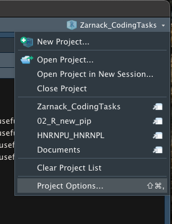

Find Project Options

A Git repository will be created for the project. You may be asked to restart Posit/RStudio.

**Task:** Set up an RStudio project with Git version control for one of your own projects or for a test project.

## 8.3 Commit in Posit/RStudio

After Git is enabled, you should see a Git pane in Posit/RStudio.

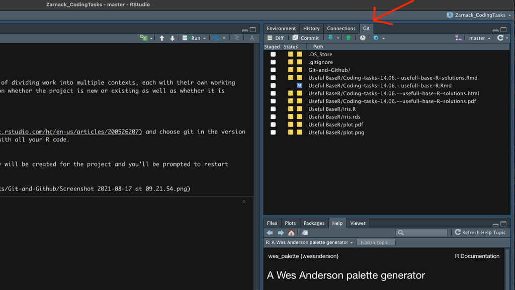

Git pane in RStudio

The Git pane shows files that have changed since the last commit.

Common file states:

| State | Meaning |
| --- | --- |
| Untracked | Git does not yet track this file |
| Modified | File changed since the last commit |
| Staged | File selected for the next commit |
| Deleted | File was removed |

To commit in Posit/RStudio:

1. Open the Git pane.
2. Select files you want to include (clicking them functions as “git add” and adds them to the staging area .
3. Click **Commit** (functions as “git commit”)

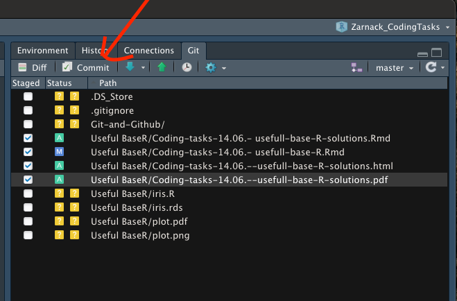

Commit your changes

4. You will see all changes in your code since the last version marked in green and red. Review the changes.

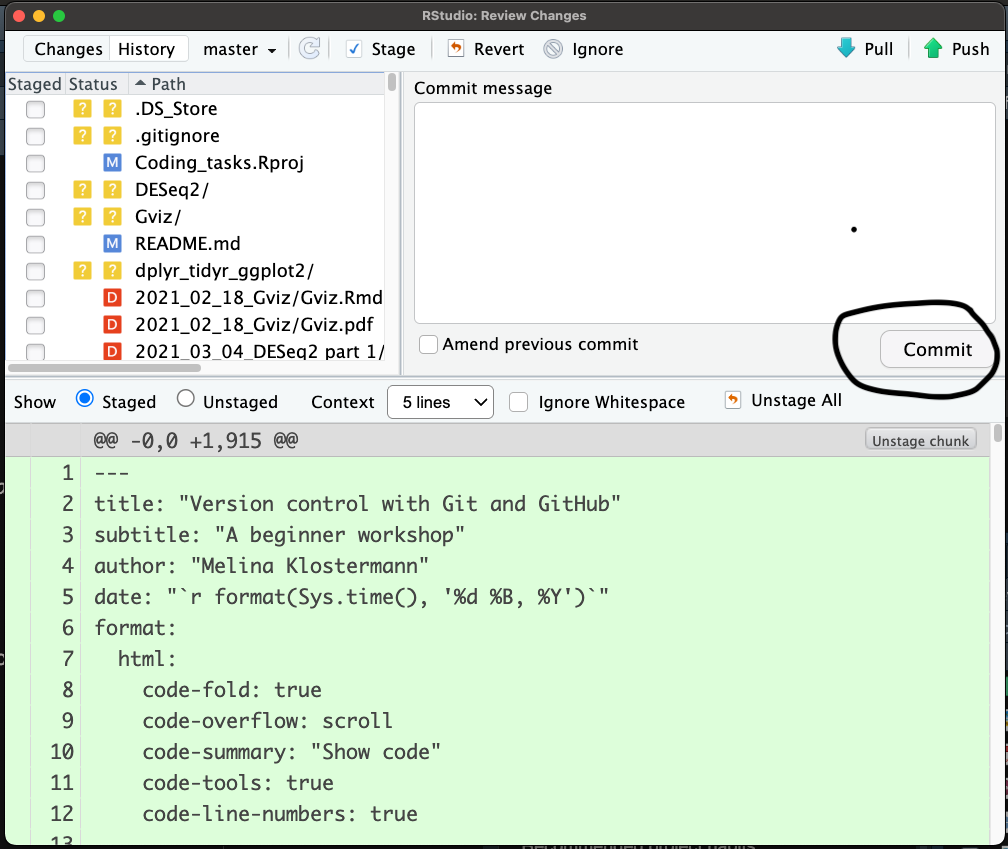

Commit window

5. Write a meaningful commit message.
6. Click **Commit**.

Good commit messages are short but specific:

```
Add sample metadata
Fix normalization bug
Update PCA plot labels
Add differential expression script
```

Avoid messages like:

```
changes
stuff
final
update
```

A useful rule:

> Commit whenever you reach a meaningful milestone.

For example:

- you cleaned metadata
- you generated QC plots
- you fixed a bug
- you added a new analysis step
- you changed a figure for a presentation

**Task:** Make a small change to a file in your RStudio project and commit it.

## 8.4 Push and pull in Posit/RStudio

### 8.4.1 Pull from GitHub

Click the “Pull” down arrow in the Git pane to pull changes from GitHub.

This corresponds to:

```bash
git pull
```

### 8.4.2 Push to GitHub

Click the “Push” up arrow in the Git pane to push your local commits to GitHub.

This corresponds to:

```bash
git push
```

Typical workflow:

```
Open project
↓
Pull
↓
Edit files
↓
Commit
↓
Push
```

**Task:** Push your committed change to GitHub.

## 8.5 Revisit older versions

Click the history/clock symbol in the Git pane.

You can inspect older commits to see what changed.

# 9 Part 4: After thoughts

## 9.1 Common beginner mistakes and how to recover

Git can feel scary at first, but many mistakes are reversible.

### 9.1.1 I want to see what changed

```bash
git diff
```

### 9.1.2 I staged the wrong file

```bash
git restore --staged file.txt
```

### 9.1.3 I changed a file but want to discard the changes

```bash
git restore file.txt
```

Be careful: this removes your uncommitted changes in that file.

### 9.1.4 I forgot what I committed

```bash
git log --oneline
```

### 9.1.5 I do not know what state my repository is in

```bash
git status
```

When in doubt, run `git status` first.

## 9.2 Recommended project habits

- Use one Git repository per project.
- Commit small, meaningful changes.
- Write informative commit messages.
- Push after committing important work.
- Use `.gitignore` from the beginning.
- Do not commit sensitive data.
- Keep raw data separate from code when files are large.
- Add a `README.md` explaining what the project is and how to run it.

# 10 Git cheat sheet

```bash
# Check repository state
git status

# Show file changes
git diff

# Stage one file
git add file.txt

# Stage all changed files
git add .

# Commit staged files
git commit -m "Meaningful commit message"

# Show history
git log --oneline

# Add GitHub remote
git remote add origin https://github.com/USERNAME/REPOSITORY.git

# Push to GitHub
git push

# Pull from GitHub
git pull

# Clone repository
git clone https://github.com/USERNAME/REPOSITORY.git

# Unstage a file
git restore --staged file.txt

# Discard unstaged changes in a file
git restore file.txt
```

# 11 Take-home message

For researchers, Git is a practical tool for:

- reproducibility
- project organization
- collaboration
- tracking analysis changes
- timestamps
- recovering from mistakes

You do not need to know all of Git to benefit from it.

Start with:

```bash
git status
git add
git commit
git pull
git push
```

Then build up from there.